# NYC Taxi Duration Exploratory Data Analysis

kimnewzealand

9 August 2017

## SYNOPSIS

The New York City Taxi Trip Duration [Kaggle competition](https://www.kaggle.com/c/nyc-taxi-trip-duration) launched on 21 July 2017 is a competition given train and test data sets, with the objective of predicting trip durations.

This is an Exploratory Data Analysis prior to the Data Modelling and Predictions which will be reported in a separate document.

We will use different methods for our analysis to enable us to have different views of the data and compare the results. We will also use different techniques for dealing with large datasets such as data.table and random row sampling.

## Setup

### Load Libraries

```r
library(data.table)
library(knitr)
library(ggplot2)
library(GGally)
library(ggmap)
library(maps)
library(mapdata)
library(mapview)
library(leaflet)
library(dplyr)
library(taRifx)
```

## Part 1: Data

### 1.1. Load Data

The first step will be to load the data description, test and train data file using the fread function from the R package data.table.

### 1.2 Data Structure and Summary

- There are 1458644 rows with 11 variables in train.
- There are 625134 rows with 9 variables in test.

Train has two additional fields *trip_duration* and dropoff_datetime to the test set. The variable *trip_duration* is the independent, response variable we are trying to predict and is derived as the difference between dropoff_datetime and pickup_datetime.

Each row in the datasets represent one taxi trip.

All variable headings are populated.

```r
# Summary statistics
kable(summary(train)[,1:5])
```

|  | id | vendor_id | pickup_datetime | dropoff_datetime | passenger_count |
| --- | --- | --- | --- | --- | --- |
|  | Length:1458644 | Min. :1.000 | Length:1458644 | Length:1458644 | Min. :0.000 |
|  | Class :character | 1st Qu.:1.000 | Class :character | Class :character | 1st Qu.:1.000 |
|  | Mode :character | Median :2.000 | Mode :character | Mode :character | Median :1.000 |
|  | NA | Mean :1.535 | NA | NA | Mean :1.665 |
|  | NA | 3rd Qu.:2.000 | NA | NA | 3rd Qu.:2.000 |
|  | NA | Max. :2.000 | NA | NA | Max. :9.000 |

```r
kable(summary(train)[,6:11])
```

|  | pickup_longitude | pickup_latitude | dropoff_longitude | dropoff_latitude | store_and_fwd_flag | trip_duration |
| --- | --- | --- | --- | --- | --- | --- |
|  | Min. :-121.93 | Min. :34.36 | Min. :-121.93 | Min. :32.18 | Length:1458644 | Min. : 1 |
|  | 1st Qu.: -73.99 | 1st Qu.:40.74 | 1st Qu.: -73.99 | 1st Qu.:40.74 | Class :character | 1st Qu.: 397 |
|  | Median : -73.98 | Median :40.75 | Median : -73.98 | Median :40.75 | Mode :character | Median : 662 |
|  | Mean : -73.97 | Mean :40.75 | Mean : -73.97 | Mean :40.75 | NA | Mean : 959 |
|  | 3rd Qu.: -73.97 | 3rd Qu.:40.77 | 3rd Qu.: -73.96 | 3rd Qu.:40.77 | NA | 3rd Qu.: 1075 |
|  | Max. : -61.34 | Max. :51.88 | Max. : -61.34 | Max. :43.92 | NA | Max. :3526282 |

We can expand on the data field information provided by Kaggle with the above summary information:

**EXPLANATORY VARIABLES/ FEATURES**  
- **id** character. A unique identifier for each trip.  
- **vendor_id** integer. A code indicating the provider associated with the trip record. There appears to be 2 taxi companies.  
- **pickup_datetime** character. The date and time when the meter was engaged. This is currently a combination of date and time.  
- **dropoff_datetime** character. The date and time when the meter was disengaged. As above this is a combination of date and time.  
- **passenger_count** integer. The number of passengers in the vehicle (driver entered value). This is a count from up to 9.  
- **pickup_longitude** numeric. The longitude where the meter was engaged. These are geographical coordinates and appear to be in the correct format.  
- **pickup_latitude** numeric. The latitude where the meter was engaged.  
- **dropoff_longitude** numeric. The longitude where the meter was disengaged.  
- **dropoff_latitude** numeric. The latitude where the meter was disengaged.  
- **store_and_fwd_flag** character. This flag indicates whether the trip record was held in vehicle memory before sending to the vendor because the vehicle did not have a connection to the server. Y=store and forward; N=not a store and forward trip.

**RESPONSE VARIABLE/ OUTCOME**  
- **trip_duration** integer. The duration of the trip in seconds.

### 1.3. Missing Values

There are 0 NA missing values in the dataset.

### 1.4. Sample Train Data

Since this is a large dataset we will use a random sample of rows for EDA plots.

```r
# Convert variables to factor and numeric classes for EDA
train$vendor_id <-as.factor(train$vendor_id)
train$passenger_count <-as.factor(train$passenger_count)
train$trip_duration <-as.numeric(train$trip_duration)
train$store_and_fwd_flag <-as.factor(train$store_and_fwd_flag)

# Random sample subset of train data for EDA, set seed to be reproduceable
set.seed(123)
trainsample <- sample_n(train, 10000)
testsample <- sample_n(test, 10000)
```

## Part 2: Exploratory Data Analysis

### 2.1. Plots of Categorical Variables

Let’s first take a look at the plots between the categorical variables and the *trip_duration* using ggpairs function from the R package GGally.

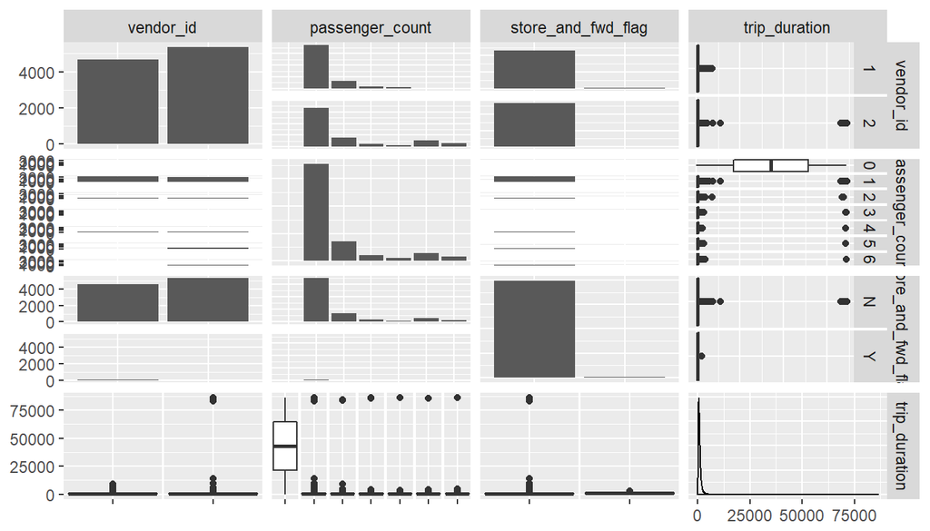

```r
# Plot sample train data
ggpairs(trainsample[,c("vendor_id", "passenger_count", "store_and_fwd_flag","trip_duration")], upper = list(continuous = "points", combo = "box"), lower = list(continuous = "points", combo = "box"))
```

Let’s review each of the variables in turn:

2.1.1 RESPONSE VARIABLE TRIP_DURATION

The variable trip_duration is right skewed with very long tail. We will therefore take the log to normalise the distribution. Let’s check the new plot:

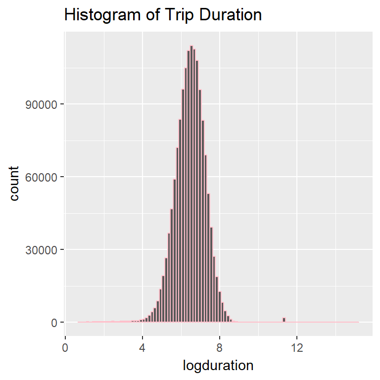

```r
# Add a column of log of the duration
train <-  train %>%
    mutate(logduration=log(trip_duration+1))
# Plot the  log duration for comparison
g <- ggplot(data=train,aes(logduration))
g + geom_histogram(col="pink",bins=100) +
    labs(title="Histogram of Trip Duration")
```

The log of the trip_duration is normally distributed, although with a high peak. If we use this form of the response variable in the data modelling, we will need to remember convert the log trip duration back to original form later.

There appear to be some outliers in *trip_duration*, with the max value 3.52628210^{6} which equates to 41 days. We make the assumption that the meter has to be actively disengaged, there may be trips where the driver forgot to turn off the meter on drop off.

2.1.2 PASSENGER COUNT

The passenger count is a right skewed distribution, which we could expect: most cab rides have single or few passengers. [Offical NY Taxis](http://www.nyc.gov/html/tlc/html/faq/faq_pass.shtml#3) can take a maximum of 5 passengers.

```r
kable(summary(train$passenger_count),format="html")
```

| 0 | 60 |
| --- | --- |
| 1 | 1033540 |
| 2 | 210318 |
| 3 | 59896 |
| 4 | 28404 |
| 5 | 78088 |
| 6 | 48333 |
| 7 | 3 |
| 8 | 1 |
| 9 | 1 |

We may want to look into the largest taxi cab size by taxi company to validate the number of passengers range.

[Official NY taxis](http://www.nyc.gov/html/tlc/html/faq/faq_pass.shtml) can take up to 5 passengers however there are [NYC limo companies](https://nyclimousine.com/) that take up to 10 passengers. Therefore we will leave the passenger number variable unchanged as we do not know the names of the vendors in this dataset.

Let’s view the passenger numbers against *trip_duration* and split by the vendor id in a boxplot.

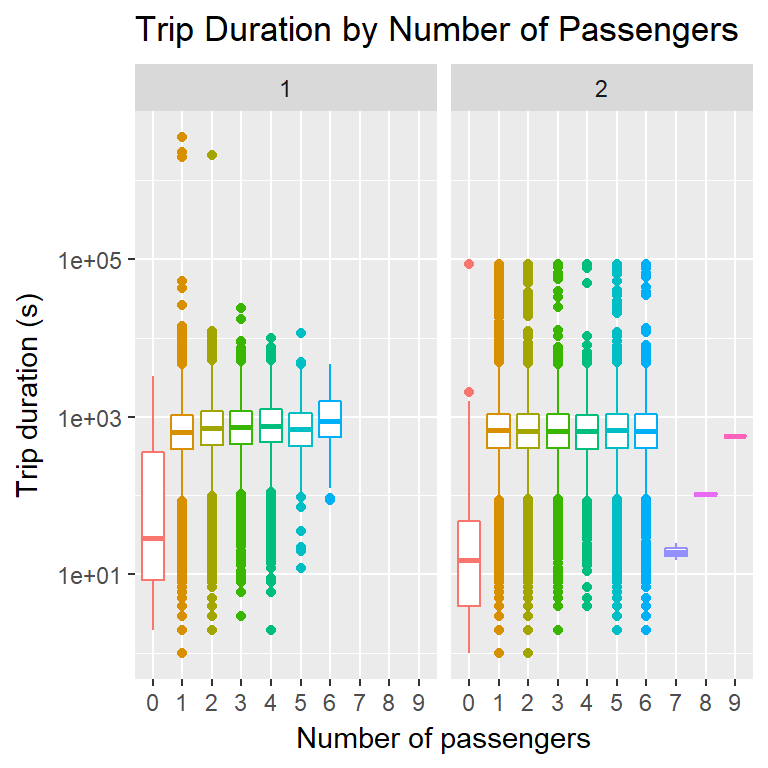

```r
g <- ggplot(train,aes(as.factor(passenger_count), trip_duration, color = passenger_count))
g +  geom_boxplot() +
    scale_y_log10() +
    theme(legend.position = "none") +
    facet_wrap(~ vendor_id) +
    labs(title = "Trip Duration by Number of Passengers", x = "Number of passengers",y= "Trip duration (s)")
```

From the plots there appears to be some correlation between the passenger count and trip duration for vendor 1. We can also see 0 passenger number taxi trips?! We may want to remove these from our model training.

2.1.3 STORE AND FORWARD FLAG

From the above ggpairs plot there appears to little correlation between store_and_fwd_flag and the *trip duration* but there may be a relationship to vendor_id outliers.

2.1.4 VENDOR ID

### 2.2. Plots of Numerical Variables

We will only be analysing the pickup datetime variable not the drop off datetime variable as this is not in the test dataset, and we will likely remove the dropoff_datetime from our training set.

The other numerical features are the pickup and dropoff longitude and latitude variables are geographical coordinates.

2.2.1. PICKUP_DATETIME

Let’s also take a look at the pickup_datetime variable against the trip_duration, colour coded by the vendor_id.

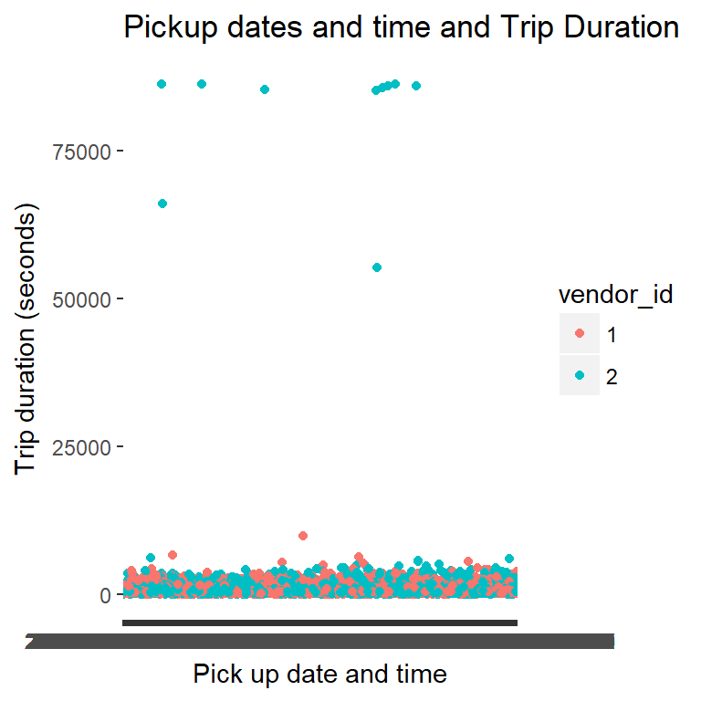

```r
# Convert the datetime variables with class POSIXct
train$pickup_datetime <- as.POSIXct(train$pickup_datetime)
# ScatterPlot the pick up date and time against trip_duration on trainsample
g <- ggplot(trainsample, aes(pickup_datetime,trip_duration,colour=vendor_id))
g + geom_point() +
    labs(title = "Pickup dates and time and Trip Duration",x="Pick up date and time",y="Trip duration (seconds)")
```

Based on this plot there appear to be outliers scattered above a threshold 10,000 second duration by vendor 2.

2.2.2. PICKUP_LATITUDE AND PICKUP_LONGITUDE

2.2.2.1. Produce map using ggpairs

We will first take a look a ggpairs plot for any outliers then look at some of the location coordinates using maps.

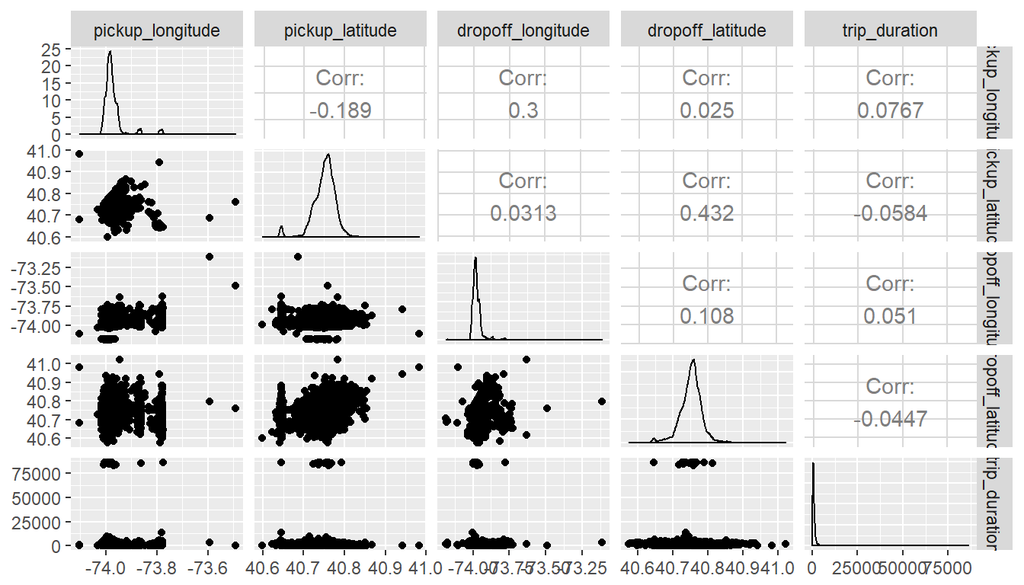

```r
# Plot a subset of train pickup and drop off date and times
ggpairs(trainsample %>% select(pickup_longitude,pickup_latitude,dropoff_longitude,dropoff_latitude,trip_duration))
```

There are some longitude and latitude outliers outside of the New York area.

Since 24 hours is 86,400 seconds there may be a reset on the taxi meters to explain this threshold. We may want to exclude *trip_duration* above this threshold in the modeling.

2.2.2.2. Produce map using function map_data function from ggplot2

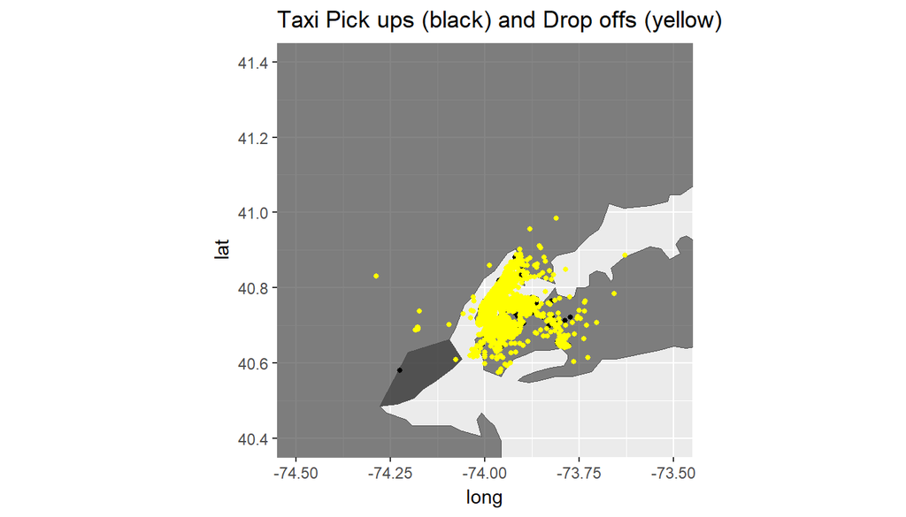

```r
# Create a smaller dataframe for EDA plotting since this is a very large dataset, that will work with ggplot2 and function map_data function from ggplot2
maptrain <- trainsample[,6:9]
maptrain<- maptrain %>%
    mutate(group =1)
order<-as.data.frame(c(1:dim(maptrain)[1]))
names(order)<-"order"
maptrain<- cbind(maptrain,order)
maptrain<- maptrain %>%
  mutate(region ="USA")
maptrainpick <-maptrain[,-(3:4)]
maptraindrop <-maptrain[,-(1:2)]
usa <- map_data("usa")
# Plot using ggplot
ggplot() +
    geom_polygon(data = usa, aes(x=long, y = lat, group = group), color = "grey30", alpha = 0.6, size = 0.3) +
    coord_fixed(xlim = c(-74.5, -73.5), ylim = c(40.4,41.4)) +
    geom_point(data = maptrainpick, aes(x = pickup_longitude, y = pickup_latitude), color = "black", size = 1) +
    geom_point(data = maptraindrop, aes(x = dropoff_longitude, y = dropoff_latitude), color = "yellow", size = 1) +
    ggtitle("Taxi Pick ups (black) and Drop offs (yellow)")
```

2.2.2.3. Produce map using ggmap

Next we will take a look at mapping New York using the R package ggmap.

[figure not shown]

```r
# Create a base map of New York City
nymap <- get_map(location = "New York", maptype = "roadmap", zoom = 11)
g <- ggmap(nymap)
# Add coordinates from train as layers to the base plot
g + theme_void() +
    ggtitle("Taxi Pick ups (black) and Drop offs (yellow)")+
    geom_point(data = trainsample, aes(x = pickup_longitude, y = pickup_latitude), color = "black", size = 1) +
    geom_point(data = trainsample, aes(x = dropoff_longitude, y = dropoff_latitude), color = "yellow", size = 1) +
    theme_void()
```

2.2.2.4. Produce map using leaflet

Lastly let’s view using the R package leaflet to produce an interactive map of New York City plotting the pick up and drop off coordinates. This will allow us to get an idea of the coordinates of the different areas and airports in New York.

```r
# Plot the pickup locations and the drop off locations
map1 <- leaflet(trainsample) %>% # initiate the leaflet instance
    addTiles() %>%  #add map tiles - the default is openstreetmap
    setView(-73.9, 40.75, zoom = 11) %>%
    addCircles(~pickup_longitude, ~pickup_latitude, weight = 1, radius=10,
                 color="red", stroke = TRUE, fillOpacity = 0.8) %>%
    addCircles(~dropoff_longitude, ~dropoff_latitude, weight = 1, radius=10,
                 color="blue", stroke = TRUE, fillOpacity = 0.8) %>%
    addLegend("bottomright", colors= "blue", labels="Drop off Location in TRain data", title="In New York City") %>%
    addLegend("topright", colors= "red", labels="Pick up Location Train data", title="In New York City") %>%
    addMouseCoordinates(style = "basic")
map1
```

[interactive chart not shown]